# Risk Factor Analysis

## Outcome Variable

**Outcome Variable:** stunted

## Predictor Variables

**Intervention Variable:** vagbrth

**Adjustment Set:**

- arm
- sex
- W_mage
- meducyrs
- feducyrs
- hhwealth_quart
- hfoodsec
- W_mhtcm
- W_nrooms
- W_nchldlt5
- brthmon
- W_parity
- impfloor
- impsan
- safeh20
- delta_W_mage
- delta_meducyrs
- delta_feducyrs
- delta_hhwealth_quart
- delta_hfoodsec
- delta_W_mhtcm
- delta_W_nrooms
- delta_W_nchldlt5
- delta_brthmon
- delta_W_parity
- delta_impfloor
- delta_impsan
- delta_safeh20

## Stratifying Variables

The analysis was stratified on these variable(s):

- agecat
- studyid
- country

## Data Summary

| agecat | studyid | country | vagbrth | stunted | n_cell | n |
| --- | --- | --- | --- | --- | --- | --- |
| Birth | ki1000108-CMC-V-BCS-2002 | INDIA | 0 | 0 | 9 | 90 |
| Birth | ki1000108-CMC-V-BCS-2002 | INDIA | 0 | 1 | 2 | 90 |
| Birth | ki1000108-CMC-V-BCS-2002 | INDIA | 1 | 0 | 65 | 90 |
| Birth | ki1000108-CMC-V-BCS-2002 | INDIA | 1 | 1 | 14 | 90 |
| Birth | ki1000108-IRC | INDIA | 0 | 0 | 58 | 388 |
| Birth | ki1000108-IRC | INDIA | 0 | 1 | 10 | 388 |
| Birth | ki1000108-IRC | INDIA | 1 | 0 | 285 | 388 |
| Birth | ki1000108-IRC | INDIA | 1 | 1 | 35 | 388 |
| Birth | ki1017093c-NIH-Crypto | BANGLADESH | 0 | 0 | 1 | 19 |
| Birth | ki1017093c-NIH-Crypto | BANGLADESH | 0 | 1 | 0 | 19 |
| Birth | ki1017093c-NIH-Crypto | BANGLADESH | 1 | 0 | 15 | 19 |
| Birth | ki1017093c-NIH-Crypto | BANGLADESH | 1 | 1 | 3 | 19 |
| Birth | ki1119695-PROBIT | BELARUS | 0 | 0 | 1594 | 13884 |
| Birth | ki1119695-PROBIT | BELARUS | 0 | 1 | 3 | 13884 |
| Birth | ki1119695-PROBIT | BELARUS | 1 | 0 | 12257 | 13884 |
| Birth | ki1119695-PROBIT | BELARUS | 1 | 1 | 30 | 13884 |
| Birth | ki1126311-ZVITAMBO | ZIMBABWE | 0 | 0 | 1073 | 13716 |
| Birth | ki1126311-ZVITAMBO | ZIMBABWE | 0 | 1 | 89 | 13716 |
| Birth | ki1126311-ZVITAMBO | ZIMBABWE | 1 | 0 | 11233 | 13716 |
| Birth | ki1126311-ZVITAMBO | ZIMBABWE | 1 | 1 | 1321 | 13716 |
| Birth | kiGH5241-JiVitA-3 | BANGLADESH | 0 | 0 | 4 | 39172 |
| Birth | kiGH5241-JiVitA-3 | BANGLADESH | 0 | 1 | 2 | 39172 |
| Birth | kiGH5241-JiVitA-3 | BANGLADESH | 1 | 0 | 26512 | 39172 |
| Birth | kiGH5241-JiVitA-3 | BANGLADESH | 1 | 1 | 12654 | 39172 |
| Birth | kiGH5241-JiVitA-4 | BANGLADESH | 0 | 0 | 2 | 1644 |
| Birth | kiGH5241-JiVitA-4 | BANGLADESH | 0 | 1 | 0 | 1644 |
| Birth | kiGH5241-JiVitA-4 | BANGLADESH | 1 | 0 | 1148 | 1644 |
| Birth | kiGH5241-JiVitA-4 | BANGLADESH | 1 | 1 | 494 | 1644 |
| 6 months | ki1000108-CMC-V-BCS-2002 | INDIA | 0 | 0 | 17 | 369 |
| 6 months | ki1000108-CMC-V-BCS-2002 | INDIA | 0 | 1 | 8 | 369 |

[output cut: 70 more lines]

The following strata were considered:

- agecat: 24 months, studyid: ki1000108-CMC-V-BCS-2002, country: INDIA
- agecat: 24 months, studyid: ki1000108-IRC, country: INDIA
- agecat: 24 months, studyid: ki1017093b-PROVIDE, country: BANGLADESH
- agecat: 24 months, studyid: ki1017093c-NIH-Crypto, country: BANGLADESH
- agecat: 24 months, studyid: ki1066203-TanzaniaChild2, country: TANZANIA, UNITED REPUBLIC OF
- agecat: 24 months, studyid: ki1119695-PROBIT, country: BELARUS
- agecat: 24 months, studyid: ki1126311-ZVITAMBO, country: ZIMBABWE
- agecat: 24 months, studyid: kiGH5241-JiVitA-3, country: BANGLADESH
- agecat: 24 months, studyid: kiGH5241-JiVitA-4, country: BANGLADESH
- agecat: 6 months, studyid: ki1000108-CMC-V-BCS-2002, country: INDIA
- agecat: 6 months, studyid: ki1000108-IRC, country: INDIA
- agecat: 6 months, studyid: ki1017093b-PROVIDE, country: BANGLADESH
- agecat: 6 months, studyid: ki1017093c-NIH-Crypto, country: BANGLADESH
- agecat: 6 months, studyid: ki1066203-TanzaniaChild2, country: TANZANIA, UNITED REPUBLIC OF
- agecat: 6 months, studyid: ki1119695-PROBIT, country: BELARUS
- agecat: 6 months, studyid: ki1126311-ZVITAMBO, country: ZIMBABWE
- agecat: 6 months, studyid: kiGH5241-JiVitA-3, country: BANGLADESH
- agecat: 6 months, studyid: kiGH5241-JiVitA-4, country: BANGLADESH
- agecat: Birth, studyid: ki1000108-CMC-V-BCS-2002, country: INDIA
- agecat: Birth, studyid: ki1000108-IRC, country: INDIA
- agecat: Birth, studyid: ki1017093c-NIH-Crypto, country: BANGLADESH
- agecat: Birth, studyid: ki1119695-PROBIT, country: BELARUS
- agecat: Birth, studyid: ki1126311-ZVITAMBO, country: ZIMBABWE
- agecat: Birth, studyid: kiGH5241-JiVitA-3, country: BANGLADESH
- agecat: Birth, studyid: kiGH5241-JiVitA-4, country: BANGLADESH

### Dropped Strata

Some strata were dropped due to rare outcomes:

- agecat: Birth, studyid: ki1000108-CMC-V-BCS-2002, country: INDIA
- agecat: Birth, studyid: ki1017093c-NIH-Crypto, country: BANGLADESH
- agecat: Birth, studyid: ki1119695-PROBIT, country: BELARUS
- agecat: Birth, studyid: kiGH5241-JiVitA-3, country: BANGLADESH
- agecat: Birth, studyid: kiGH5241-JiVitA-4, country: BANGLADESH
- agecat: 24 months, studyid: ki1066203-TanzaniaChild2, country: TANZANIA, UNITED REPUBLIC OF

## Methods Detail

We’re interested in the causal parameters $E[Y_a]$ for all values of $a \in \mathcal{A}$. These parameters represent the mean outcome if, possibly contrary to fact, we intervened to set all units to have $A=a$. Under the randomization and positivity assumptions, these are identified by the statistical parameters $\psi_a=E_W[E_{Y|A,W}(Y|A=a,W)]$. In addition, we’re interested in the mean of $Y$, $E[Y]$ under no intervention (the observed mean). We will estimate these parameters by using SuperLearner to fit the relevant likelihood factors – $E_{Y|A,W}(Y|A=a,W)$ and $p(A=a|W)$, and then updating our likelihood fit using a joint TMLE.

For unadjusted analyses ($W=\{\}$), initial likelihoods were estimated using Lrnr_glm to estimate the simple $E(Y|A)$ and Lrnr_mean to estimate $p(A)$. For adjusted analyses, a small library containing Lrnr_glmnet, Lrnr_xgboost, and Lrnr_mean was used.

Having estimated these parameters, we will then use the delta method to estimate relative risks and attributable risks relative to a prespecified baseline level of $A$.

# Results Detail

## Results Plots

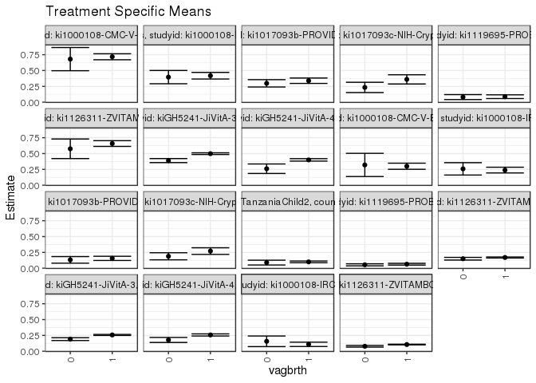

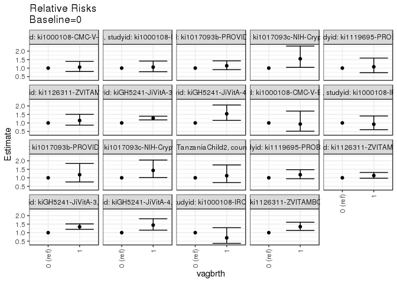

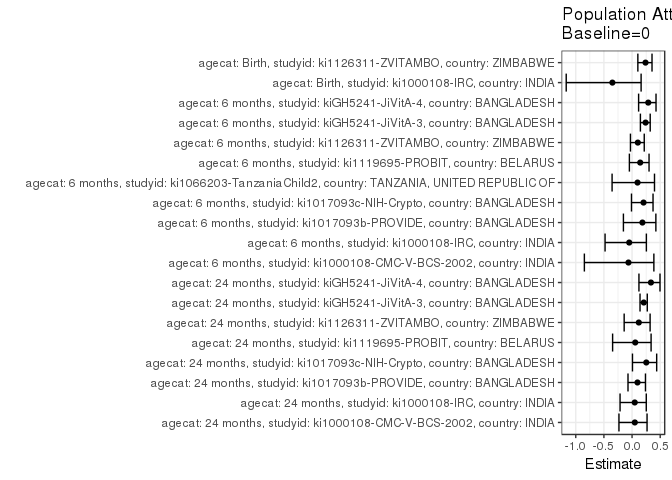

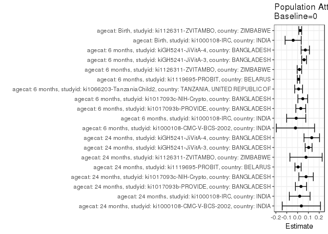

## Results Table

### Parameter: TSM

| agecat | studyid | country | intervention_level | baseline_level | estimate | ci_lower | ci_upper |
| --- | --- | --- | --- | --- | --- | --- | --- |
| Birth | ki1000108-IRC | INDIA | 0 | NA | 0.1564885 | 0.0726259 | 0.2403511 |
| Birth | ki1000108-IRC | INDIA | 1 | NA | 0.1087343 | 0.0746051 | 0.1428635 |
| Birth | ki1126311-ZVITAMBO | ZIMBABWE | 0 | NA | 0.0782260 | 0.0649623 | 0.0914898 |
| Birth | ki1126311-ZVITAMBO | ZIMBABWE | 1 | NA | 0.1056963 | 0.1003342 | 0.1110585 |
| 6 months | ki1000108-CMC-V-BCS-2002 | INDIA | 0 | NA | 0.3200000 | 0.1368964 | 0.5031036 |
| 6 months | ki1000108-CMC-V-BCS-2002 | INDIA | 1 | NA | 0.2994186 | 0.2509538 | 0.3478835 |
| 6 months | ki1000108-IRC | INDIA | 0 | NA | 0.2580653 | 0.1604829 | 0.3556477 |
| 6 months | ki1000108-IRC | INDIA | 1 | NA | 0.2384547 | 0.1930555 | 0.2838538 |
| 6 months | ki1017093b-PROVIDE | BANGLADESH | 0 | NA | 0.1315523 | 0.0792429 | 0.1838617 |
| 6 months | ki1017093b-PROVIDE | BANGLADESH | 1 | NA | 0.1552208 | 0.1221715 | 0.1882701 |
| 6 months | ki1017093c-NIH-Crypto | BANGLADESH | 0 | NA | 0.1881357 | 0.1321621 | 0.2441092 |
| 6 months | ki1017093c-NIH-Crypto | BANGLADESH | 1 | NA | 0.2702960 | 0.2179270 | 0.3226650 |
| 6 months | ki1066203-TanzaniaChild2 | TANZANIA, UNITED REPUBLIC OF | 0 | NA | 0.0886902 | 0.0509921 | 0.1263884 |
| 6 months | ki1066203-TanzaniaChild2 | TANZANIA, UNITED REPUBLIC OF | 1 | NA | 0.0997527 | 0.0860085 | 0.1134969 |
| 6 months | ki1119695-PROBIT | BELARUS | 0 | NA | 0.0536118 | 0.0374560 | 0.0697675 |
| 6 months | ki1119695-PROBIT | BELARUS | 1 | NA | 0.0633531 | 0.0495459 | 0.0771603 |
| 6 months | ki1126311-ZVITAMBO | ZIMBABWE | 0 | NA | 0.1496784 | 0.1285610 | 0.1707958 |
| 6 months | ki1126311-ZVITAMBO | ZIMBABWE | 1 | NA | 0.1694095 | 0.1609798 | 0.1778392 |
| 6 months | kiGH5241-JiVitA-3 | BANGLADESH | 0 | NA | 0.1910650 | 0.1690013 | 0.2131287 |
| 6 months | kiGH5241-JiVitA-3 | BANGLADESH | 1 | NA | 0.2569907 | 0.2487283 | 0.2652532 |
| 6 months | kiGH5241-JiVitA-4 | BANGLADESH | 0 | NA | 0.1779609 | 0.1382934 | 0.2176285 |
| 6 months | kiGH5241-JiVitA-4 | BANGLADESH | 1 | NA | 0.2569754 | 0.2400223 | 0.2739284 |
| 24 months | ki1000108-CMC-V-BCS-2002 | INDIA | 0 | NA | 0.6800000 | 0.4968984 | 0.8631016 |
| 24 months | ki1000108-CMC-V-BCS-2002 | INDIA | 1 | NA | 0.7175793 | 0.6701495 | 0.7650090 |
| 24 months | ki1000108-IRC | INDIA | 0 | NA | 0.3957975 | 0.2909712 | 0.5006239 |
| 24 months | ki1000108-IRC | INDIA | 1 | NA | 0.4179408 | 0.3656611 | 0.4702204 |
| 24 months | ki1017093b-PROVIDE | BANGLADESH | 0 | NA | 0.2975744 | 0.2396435 | 0.3555052 |
| 24 months | ki1017093b-PROVIDE | BANGLADESH | 1 | NA | 0.3386385 | 0.2959832 | 0.3812937 |
| 24 months | ki1017093c-NIH-Crypto | BANGLADESH | 0 | NA | 0.2328222 | 0.1516894 | 0.3139550 |
| 24 months | ki1017093c-NIH-Crypto | BANGLADESH | 1 | NA | 0.3601426 | 0.2871368 | 0.4331484 |
| 24 months | ki1119695-PROBIT | BELARUS | 0 | NA | 0.0804522 | 0.0411067 | 0.1197977 |
| 24 months | ki1119695-PROBIT | BELARUS | 1 | NA | 0.0865527 | 0.0571003 | 0.1160051 |
| 24 months | ki1126311-ZVITAMBO | ZIMBABWE | 0 | NA | 0.5750365 | 0.4204984 | 0.7295746 |
| 24 months | ki1126311-ZVITAMBO | ZIMBABWE | 1 | NA | 0.6578803 | 0.6125322 | 0.7032284 |
| 24 months | kiGH5241-JiVitA-3 | BANGLADESH | 0 | NA | 0.3884005 | 0.3565033 | 0.4202977 |
| 24 months | kiGH5241-JiVitA-3 | BANGLADESH | 1 | NA | 0.4980878 | 0.4847553 | 0.5114202 |
| 24 months | kiGH5241-JiVitA-4 | BANGLADESH | 0 | NA | 0.2599643 | 0.1850054 | 0.3349233 |
| 24 months | kiGH5241-JiVitA-4 | BANGLADESH | 1 | NA | 0.3995114 | 0.3803912 | 0.4186317 |

### Parameter: E(Y)

| agecat | studyid | country | intervention_level | baseline_level | estimate | ci_lower | ci_upper |
| --- | --- | --- | --- | --- | --- | --- | --- |
| Birth | ki1000108-IRC | INDIA | NA | NA | 0.1159794 | 0.0840777 | 0.1478811 |
| Birth | ki1126311-ZVITAMBO | ZIMBABWE | NA | NA | 0.1027997 | 0.0977170 | 0.1078823 |
| 6 months | ki1000108-CMC-V-BCS-2002 | INDIA | NA | NA | 0.3008130 | 0.2539566 | 0.3476694 |
| 6 months | ki1000108-IRC | INDIA | NA | NA | 0.2457002 | 0.2038248 | 0.2875757 |
| 6 months | ki1017093b-PROVIDE | BANGLADESH | NA | NA | 0.1612350 | 0.1313580 | 0.1911120 |
| 6 months | ki1017093c-NIH-Crypto | BANGLADESH | NA | NA | 0.2363239 | 0.1973320 | 0.2753157 |
| 6 months | ki1066203-TanzaniaChild2 | TANZANIA, UNITED REPUBLIC OF | NA | NA | 0.0982544 | 0.0852222 | 0.1112865 |
| 6 months | ki1119695-PROBIT | BELARUS | NA | NA | 0.0626864 | 0.0488489 | 0.0765238 |
| 6 months | ki1126311-ZVITAMBO | ZIMBABWE | NA | NA | 0.1667477 | 0.1586931 | 0.1748023 |
| 6 months | kiGH5241-JiVitA-3 | BANGLADESH | NA | NA | 0.2514795 | 0.2433525 | 0.2596064 |
| 6 months | kiGH5241-JiVitA-4 | BANGLADESH | NA | NA | 0.2498147 | 0.2337133 | 0.2659161 |
| 24 months | ki1000108-CMC-V-BCS-2002 | INDIA | NA | NA | 0.7150538 | 0.6691221 | 0.7609854 |
| 24 months | ki1000108-IRC | INDIA | NA | NA | 0.4156479 | 0.3678270 | 0.4634689 |
| 24 months | ki1017093b-PROVIDE | BANGLADESH | NA | NA | 0.3292894 | 0.2909105 | 0.3676684 |
| 24 months | ki1017093c-NIH-Crypto | BANGLADESH | NA | NA | 0.3115385 | 0.2551365 | 0.3679404 |
| 24 months | ki1119695-PROBIT | BELARUS | NA | NA | 0.0852540 | 0.0554439 | 0.1150642 |
| 24 months | ki1126311-ZVITAMBO | ZIMBABWE | NA | NA | 0.6533333 | 0.6093135 | 0.6973532 |
| 24 months | kiGH5241-JiVitA-3 | BANGLADESH | NA | NA | 0.4907607 | 0.4776332 | 0.5038882 |
| 24 months | kiGH5241-JiVitA-4 | BANGLADESH | NA | NA | 0.3910336 | 0.3723737 | 0.4096935 |

### Parameter: RR

| agecat | studyid | country | intervention_level | baseline_level | estimate | ci_lower | ci_upper |
| --- | --- | --- | --- | --- | --- | --- | --- |
| Birth | ki1000108-IRC | INDIA | 0 | 0 | 1.0000000 | 1.0000000 | 1.000000 |
| Birth | ki1000108-IRC | INDIA | 1 | 0 | 0.6948391 | 0.3736130 | 1.292250 |
| Birth | ki1126311-ZVITAMBO | ZIMBABWE | 0 | 0 | 1.0000000 | 1.0000000 | 1.000000 |
| Birth | ki1126311-ZVITAMBO | ZIMBABWE | 1 | 0 | 1.3511657 | 1.1321604 | 1.612535 |
| 6 months | ki1000108-CMC-V-BCS-2002 | INDIA | 0 | 0 | 1.0000000 | 1.0000000 | 1.000000 |
| 6 months | ki1000108-CMC-V-BCS-2002 | INDIA | 1 | 0 | 0.9356831 | 0.5162674 | 1.695832 |
| 6 months | ki1000108-IRC | INDIA | 0 | 0 | 1.0000000 | 1.0000000 | 1.000000 |
| 6 months | ki1000108-IRC | INDIA | 1 | 0 | 0.9240090 | 0.6051853 | 1.410795 |
| 6 months | ki1017093b-PROVIDE | BANGLADESH | 0 | 0 | 1.0000000 | 1.0000000 | 1.000000 |
| 6 months | ki1017093b-PROVIDE | BANGLADESH | 1 | 0 | 1.1799170 | 0.7564088 | 1.840544 |
| 6 months | ki1017093c-NIH-Crypto | BANGLADESH | 0 | 0 | 1.0000000 | 1.0000000 | 1.000000 |
| 6 months | ki1017093c-NIH-Crypto | BANGLADESH | 1 | 0 | 1.4367077 | 1.0105111 | 2.042658 |
| 6 months | ki1066203-TanzaniaChild2 | TANZANIA, UNITED REPUBLIC OF | 0 | 0 | 1.0000000 | 1.0000000 | 1.000000 |
| 6 months | ki1066203-TanzaniaChild2 | TANZANIA, UNITED REPUBLIC OF | 1 | 0 | 1.1247315 | 0.7201428 | 1.756625 |
| 6 months | ki1119695-PROBIT | BELARUS | 0 | 0 | 1.0000000 | 1.0000000 | 1.000000 |
| 6 months | ki1119695-PROBIT | BELARUS | 1 | 0 | 1.1817012 | 0.9445061 | 1.478463 |
| 6 months | ki1126311-ZVITAMBO | ZIMBABWE | 0 | 0 | 1.0000000 | 1.0000000 | 1.000000 |
| 6 months | ki1126311-ZVITAMBO | ZIMBABWE | 1 | 0 | 1.1318232 | 0.9752038 | 1.313596 |
| 6 months | kiGH5241-JiVitA-3 | BANGLADESH | 0 | 0 | 1.0000000 | 1.0000000 | 1.000000 |
| 6 months | kiGH5241-JiVitA-3 | BANGLADESH | 1 | 0 | 1.3450435 | 1.1938699 | 1.515360 |
| 6 months | kiGH5241-JiVitA-4 | BANGLADESH | 0 | 0 | 1.0000000 | 1.0000000 | 1.000000 |
| 6 months | kiGH5241-JiVitA-4 | BANGLADESH | 1 | 0 | 1.4439989 | 1.1475170 | 1.817082 |
| 24 months | ki1000108-CMC-V-BCS-2002 | INDIA | 0 | 0 | 1.0000000 | 1.0000000 | 1.000000 |
| 24 months | ki1000108-CMC-V-BCS-2002 | INDIA | 1 | 0 | 1.0552636 | 0.7997388 | 1.392431 |
| 24 months | ki1000108-IRC | INDIA | 0 | 0 | 1.0000000 | 1.0000000 | 1.000000 |
| 24 months | ki1000108-IRC | INDIA | 1 | 0 | 1.0559459 | 0.7883693 | 1.414339 |
| 24 months | ki1017093b-PROVIDE | BANGLADESH | 0 | 0 | 1.0000000 | 1.0000000 | 1.000000 |
| 24 months | ki1017093b-PROVIDE | BANGLADESH | 1 | 0 | 1.1379961 | 0.9080687 | 1.426142 |
| 24 months | ki1017093c-NIH-Crypto | BANGLADESH | 0 | 0 | 1.0000000 | 1.0000000 | 1.000000 |
| 24 months | ki1017093c-NIH-Crypto | BANGLADESH | 1 | 0 | 1.5468569 | 1.0421567 | 2.295975 |
| 24 months | ki1119695-PROBIT | BELARUS | 0 | 0 | 1.0000000 | 1.0000000 | 1.000000 |
| 24 months | ki1119695-PROBIT | BELARUS | 1 | 0 | 1.0758284 | 0.7285041 | 1.588744 |
| 24 months | ki1126311-ZVITAMBO | ZIMBABWE | 0 | 0 | 1.0000000 | 1.0000000 | 1.000000 |
| 24 months | ki1126311-ZVITAMBO | ZIMBABWE | 1 | 0 | 1.1440671 | 0.8688432 | 1.506474 |
| 24 months | kiGH5241-JiVitA-3 | BANGLADESH | 0 | 0 | 1.0000000 | 1.0000000 | 1.000000 |
| 24 months | kiGH5241-JiVitA-3 | BANGLADESH | 1 | 0 | 1.2824077 | 1.1778459 | 1.396252 |
| 24 months | kiGH5241-JiVitA-4 | BANGLADESH | 0 | 0 | 1.0000000 | 1.0000000 | 1.000000 |
| 24 months | kiGH5241-JiVitA-4 | BANGLADESH | 1 | 0 | 1.5367932 | 1.1486097 | 2.056167 |

### Parameter: PAR

| agecat | studyid | country | intervention_level | baseline_level | estimate | ci_lower | ci_upper |
| --- | --- | --- | --- | --- | --- | --- | --- |
| Birth | ki1000108-IRC | INDIA | 0 | NA | -0.0405091 | -0.1150597 | 0.0340415 |
| Birth | ki1126311-ZVITAMBO | ZIMBABWE | 0 | NA | 0.0245736 | 0.0115871 | 0.0375601 |
| 6 months | ki1000108-CMC-V-BCS-2002 | INDIA | 0 | NA | -0.0191870 | -0.1957642 | 0.1573902 |
| 6 months | ki1000108-IRC | INDIA | 0 | NA | -0.0123650 | -0.1007269 | 0.0759968 |
| 6 months | ki1017093b-PROVIDE | BANGLADESH | 0 | NA | 0.0296827 | -0.0160353 | 0.0754007 |
| 6 months | ki1017093c-NIH-Crypto | BANGLADESH | 0 | NA | 0.0481882 | 0.0031571 | 0.0932192 |
| 6 months | ki1066203-TanzaniaChild2 | TANZANIA, UNITED REPUBLIC OF | 0 | NA | 0.0095641 | -0.0264882 | 0.0456164 |
| 6 months | ki1119695-PROBIT | BELARUS | 0 | NA | 0.0090746 | -0.0019553 | 0.0201045 |
| 6 months | ki1126311-ZVITAMBO | ZIMBABWE | 0 | NA | 0.0170693 | -0.0033728 | 0.0375113 |
| 6 months | kiGH5241-JiVitA-3 | BANGLADESH | 0 | NA | 0.0604145 | 0.0382835 | 0.0825454 |
| 6 months | kiGH5241-JiVitA-4 | BANGLADESH | 0 | NA | 0.0718538 | 0.0331102 | 0.1105973 |
| 24 months | ki1000108-CMC-V-BCS-2002 | INDIA | 0 | NA | 0.0350538 | -0.1413823 | 0.2114898 |
| 24 months | ki1000108-IRC | INDIA | 0 | NA | 0.0198504 | -0.0761094 | 0.1158101 |
| 24 months | ki1017093b-PROVIDE | BANGLADESH | 0 | NA | 0.0317151 | -0.0197138 | 0.0831439 |
| 24 months | ki1017093c-NIH-Crypto | BANGLADESH | 0 | NA | 0.0787163 | 0.0122339 | 0.1451986 |
| 24 months | ki1119695-PROBIT | BELARUS | 0 | NA | 0.0048019 | -0.0238452 | 0.0334490 |
| 24 months | ki1126311-ZVITAMBO | ZIMBABWE | 0 | NA | 0.0782969 | -0.0705507 | 0.2271445 |
| 24 months | kiGH5241-JiVitA-3 | BANGLADESH | 0 | NA | 0.1023602 | 0.0703104 | 0.1344101 |
| 24 months | kiGH5241-JiVitA-4 | BANGLADESH | 0 | NA | 0.1310693 | 0.0594798 | 0.2026588 |

### Parameter: PAF

| agecat | studyid | country | intervention_level | baseline_level | estimate | ci_lower | ci_upper |
| --- | --- | --- | --- | --- | --- | --- | --- |
| Birth | ki1000108-IRC | INDIA | 0 | NA | -0.3492785 | -1.1693723 | 0.1607930 |
| Birth | ki1126311-ZVITAMBO | ZIMBABWE | 0 | NA | 0.2390438 | 0.1029379 | 0.3544991 |
| 6 months | ki1000108-CMC-V-BCS-2002 | INDIA | 0 | NA | -0.0637838 | -0.8471227 | 0.3873521 |
| 6 months | ki1000108-IRC | INDIA | 0 | NA | -0.0503257 | -0.4794080 | 0.2543070 |
| 6 months | ki1017093b-PROVIDE | BANGLADESH | 0 | NA | 0.1840958 | -0.1535097 | 0.4228920 |
| 6 months | ki1017093c-NIH-Crypto | BANGLADESH | 0 | NA | 0.2039074 | -0.0100968 | 0.3725715 |
| 6 months | ki1066203-TanzaniaChild2 | TANZANIA, UNITED REPUBLIC OF | 0 | NA | 0.0973406 | -0.3547280 | 0.3985552 |
| 6 months | ki1119695-PROBIT | BELARUS | 0 | NA | 0.1447621 | -0.0474422 | 0.3016971 |
| 6 months | ki1126311-ZVITAMBO | ZIMBABWE | 0 | NA | 0.1023659 | -0.0284725 | 0.2165596 |
| 6 months | kiGH5241-JiVitA-3 | BANGLADESH | 0 | NA | 0.2402362 | 0.1482295 | 0.3223044 |
| 6 months | kiGH5241-JiVitA-4 | BANGLADESH | 0 | NA | 0.2876282 | 0.1164441 | 0.4256464 |
| 24 months | ki1000108-CMC-V-BCS-2002 | INDIA | 0 | NA | 0.0490226 | -0.2327896 | 0.2664133 |
| 24 months | ki1000108-IRC | INDIA | 0 | NA | 0.0477577 | -0.2131992 | 0.2525832 |
| 24 months | ki1017093b-PROVIDE | BANGLADESH | 0 | NA | 0.0963137 | -0.0720704 | 0.2382506 |
| 24 months | ki1017093c-NIH-Crypto | BANGLADESH | 0 | NA | 0.2526695 | 0.0074284 | 0.4373173 |
| 24 months | ki1119695-PROBIT | BELARUS | 0 | NA | 0.0563243 | -0.3454685 | 0.3381310 |
| 24 months | ki1126311-ZVITAMBO | ZIMBABWE | 0 | NA | 0.1198421 | -0.1402067 | 0.3205812 |
| 24 months | kiGH5241-JiVitA-3 | BANGLADESH | 0 | NA | 0.2085746 | 0.1415577 | 0.2703597 |
| 24 months | kiGH5241-JiVitA-4 | BANGLADESH | 0 | NA | 0.3351868 | 0.1223568 | 0.4964051 |